# Calculation of ecological indicators index

Ecological index for forest and mountain

Author

Affiliation

Aud Helen Halbritter

University of Bergen

Published

July 1, 2026

> **Recommended citation**: Halbritter, A. H. 2026. Index (ID(s): NO_INDEX_001) v. 1.0.0. ecRxiv: https://github.com/NINAnor/ecRxiv

## 1. Aim

NO_INDEX_001 combines published ecRxiv indicator uncertainty distributions into composite indices for **forest** and **mountain** ecosystems, separately by region, for Norway, and for ECT classes. Values near 1 indicate better ecological condition relative to reference; values toward 0 indicate deterioration.

## 2. Datasets

First, we check which indicators are included in each index and where their results can be found on ecRxiv.

**Indicator lists** Forest indicators are listed in `data/indicators_2026.csv`; mountain indicators follow [ECA_2026 #104](https://github.com/NINAnor/ECA_2026/issues/104) in `data/indicators_mountain.csv`. Each row specifies the indicator name, ecRxiv ID, and ECT class assignment.

```r
# Refresh manifest from local git (upstream main + submission-* branches)
invisible(tryCatch(
  scan_git_indicator_sources(git_remote = "upstream"),
  error = function(e) invisible(NULL)
))
```

**Source manifest** `scan_git_indicator_sources()` searches the local `upstream` git remote (main and `submission-*` branches) for published result files (CSV, RDS, parquet) and writes `data/indicator_sources.csv`. Optional manual or fork entries can be added in `data/indicator_sources_extra.csv` if results are not yet on `upstream`. This manifest is used internally when resolving result paths; it is not shown in the document. If the scan finds few entries, run `git fetch upstream` from the project root to refresh local branch refs.

**Registry** `build_indicator_registry()` joins the indicator lists with the manifest, probes each candidate URL or local path, and records whether results are available (`match_status`: `matched` or `no_results`). The tables below show the outcome for forest and mountain. Only `matched` indicators proceed to the analysis in Section 3.

```r
n_sim <- 1000
n_years <- 2

registry_forest <- build_indicator_registry(
  here("data/indicators_2026.csv"),
  ecosystem = "forest",
  write_path = here("data/indicators_registry_forest.csv")
)

registry_mountain <- build_indicator_registry(
  here("data/indicators_mountain.csv"),
  ecosystem = "mountain",
  write_path = here("data/indicators_registry_mountain.csv")
)
```

```r
# Compact included / not-included overview (instead of long coverage lists)
registry_status_table <- function(registry, caption) {
  registry |>
    dplyr::transmute(
      ECT = .data$ect,
      Indicator = .data$indicatorName,
      ID = .data$indicatorID,
      Status = dplyr::case_when(
        .data$match_status == "matched" ~ "Included",
        .data$match_status == "no_results" ~ "No results yet",
        TRUE ~ "Missing ID"
      )
    ) |>
    dplyr::arrange(.data$ECT, .data$Status, .data$Indicator) |>
    knitr::kable(caption = caption)
}

registry_status_table(registry_forest, "Forest indicators — inclusion status")
```

Forest indicators — inclusion status

| ECT | Indicator | ID | Status |
| --- | --- | --- | --- |
| A1 | Ditching | NO_AIVS_001 | Included |
| A1 | Moisture impacts on vegetation | NO_FUMO_004 | Included |
| A2 | Nitrogen impacts on vegetation | NO_FUNI_004 | Included |
| B1 | Alien conifers | NO_AATS_002 | Included |
| B1 | Alien plantspecies | NO_ALIE_004 | Included |
| B1 | Bumblebees | NO_BUMB_002 | Included |
| B1 | Butterflies | NO_BFLY_002 | Included |
| B1 | Dead wood volume | NO_DTVS_001 | Included |
| B2 | Dead wood share | NO_DWTO_001 | Included |
| B2 | Large trees | NO_DLTA_001 | Included |
| B2 | Multi-layered forest | NO_MLFA_001 | Included |
| B3 | Bilberry cover | NO_BLAA_001 | Included |
| B3 | Brown bear | NO_BAER_001 | Included |
| B3 | Lynx | NO_LYNX_001 | Included |
| B3 | Moose | NO_MOOS_001 | Included |
| B3 | Red deer | NO_DEER_001 | Included |
| B3 | Roe deer | NO_ROED_001 | Included |
| B3 | Rowan, aspen and goat willow | NO_ROSE_001 | Included |
| B3 | Wolf | NO_WOLF_001 | Included |
| C1 | Clear-cutting | NO_AIFH_001 | Included |
| C1 | Old forest | NO_BGSK_001 | Included |
| C1 | Connected low-infrastructure forest habitat | NO_CONN_001 | No results yet |

```r
registry_status_table(registry_mountain, "Mountain indicators — inclusion status")
```

Mountain indicators — inclusion status

| ECT | Indicator | ID | Status |
| --- | --- | --- | --- |
| A1 | Glacier area | NO_GLAC_001 | Included |
| B1 | Alien plants | NO_ALIE_002 | Included |
| B1 | Arctic fox | NO_AFOX_001 | Included |
| B1 | Golden eagle | NO_GOLD_001 | Included |
| B1 | Ptarmigan | NO_PTAR_001 | Included |
| B1 | Wolverine | NO_JERV_001 | Included |
| B1 | Vegetation functional indicators | NO_FUNC_xxx | No results yet |
| B3 | Small rodents | NO_RODE_001 | Included |
| B3 | Trampling disturbance | NO_SLIT_001 | Included |
| C1 | Disturbance index | NO_DIST_001 | No results yet |

## 3. Analyses

Forest and mountain indices are calculated separately using the same workflow (`calculate_index()` in `R/index_functions.R`). The indicator registries built in Section 2 are the input to this section.

### 3.1 Loading and harmonising indicator draws

For each `matched` indicator in the registry, `load_registry_draws()` fetches the resolved results file and harmonises it to a common structure (`year`, `part`, `value`). Supported source formats include:

- standard CSV (`year`, `part`, `sampled_mean`);
- period-based CSV or RDS (`period`, `region`/`region_code`, `sampled_mean`);
- regional RDS with companion national RDS (`*_mc_regional.rds` + `*_mc_national.rds`);
- parquet (`year`, `part`, `value` or `sim`).

Region labels are mapped to NI regions (`C`, `E`, `S`, `W`, `N`, `Norway`) via `data/region_lookup.csv`. Each row in the loaded data is one Monte Carlo draw for a given indicator, reporting year, and region.

### 3.2 Reporting periods

Indicators do not all use the same time axis. Some publish single calendar years (`year`); others publish multi-year **reporting periods** such as `2010-2014` or `2020-2024` (`period`). These period labels also differ between indicators (length and start/end years are not standardised).

For aggregation we map each reporting period to a single calendar year using the **period end year** (`period_to_year()`, e.g. `2020-2024` → `2024`). Where the source already provides `year`, that value is kept as is. For each indicator we then retain the **last two** of these mapped years (`select_reporting_years()`), which for most current forest indicators corresponds to **2019** and **2024**. Indicators may therefore appear in different years in the index, depending on their own reporting schedule.

### 3.3 Resampling and aggregation

Aggregation uses `ecTools::ec_upscale()` with equal weights **across indicators within an ECT class**, and **across ECT classes within the index** (`n_sim = 1000` by default). Steps 1–2 are run separately for each year and each of six areas: the five NI regions (`C`, `E`, `S`, `W`, `N`) and Norway.

1. **Indicator → ECT** — within an area, one draw is resampled per indicator within each ECT class, then combined with equal weights to give an ECT-level draw (`aggregate_to_ect()`).
2. **ECT → index** — within the same area, one draw is resampled per ECT class, then combined with equal weights to give an overall index draw for that area (`aggregate_to_index()`).

This propagates uncertainty from individual indicators through ECT classes to the composite index without assuming independence beyond the structure encoded in the published indicator MC distributions.

### 3.4 Summaries

The full MC distributions (all areas) are stored for export. For reporting we summarise each ECT class and the overall index by the **median** and an approximate **95% interval** (2.5% and 97.5% quantiles). Regional and national (Norway) indices are both calculated by the same steps 1–2 above, since Norway is treated as just another area (see Section 3).

```r
forest_index <- calculate_index(
  registry_forest |> filter(match_status == "matched"),
  n_sim = n_sim,
  n_years = n_years
)
```

```r
mountain_index <- calculate_index(
  registry_mountain |> filter(match_status == "matched"),
  n_sim = n_sim,
  n_years = n_years
)
```

```r
# Single-indicator test: with one matched indicator, the index for any area
# (including Norway, using that indicator's own published national draws)
# equals that indicator's own draws for the same area.
if (sum(registry_mountain$match_status == "matched") >= 1) {
  one_reg <- registry_mountain |> filter(match_status == "matched") |> slice(1)
  one_out <- calculate_index(one_reg, n_sim = 200, n_years = 1)
  part_chk <- one_out$indicator_draws |>
    distinct(part) |>
    arrange(part) |>
    slice(1) |>
    pull(part)
  val_one <- one_out$summaries |>
    filter(level == "Index", part == part_chk) |>
    slice(1)
  src <- one_out$indicator_draws |>
    filter(part == part_chk) |>
    summarise(median = median(value), .groups = "drop")
  stopifnot(abs(val_one$median - src$median) < 0.05)
}
```

## 4. Results

Summary tables report ECT classes and the overall index for **Norway** only (both retained reporting years). Regional indices (`C`, `E`, `S`, `W`, `N`) are calculated and shown in the figures below; full draws including regions are also written to the export files in Section 5.

```r
forest_index$summaries |>
  filter(part == "Norway") |>
  arrange(year, level, id) |>
  select(year, level, id, median, q025, q975) |>
  kable(digits = 3, caption = "Forest index — Norway")
```

Forest index — Norway

| year | level | id | median | q025 | q975 |
| --- | --- | --- | --- | --- | --- |
| 2019 | ECT | A1 | 0.940 | 0.935 | 0.945 |
| 2019 | ECT | B1 | 0.579 | 0.548 | 0.615 |
| 2019 | ECT | B2 | 0.322 | 0.316 | 0.329 |
| 2019 | ECT | B3 | 0.283 | 0.254 | 0.318 |
| 2019 | ECT | C1 | 0.251 | 0.239 | 0.264 |
| 2019 | Index | Index | 0.476 | 0.466 | 0.485 |
| 2024 | ECT | A1 | 0.768 | 0.764 | 0.772 |
| 2024 | ECT | A2 | 0.529 | 0.519 | 0.538 |
| 2024 | ECT | B1 | 0.677 | 0.652 | 0.698 |
| 2024 | ECT | B2 | 0.339 | 0.332 | 0.346 |
| 2024 | ECT | B3 | 0.311 | 0.279 | 0.345 |
| 2024 | ECT | C1 | 0.506 | 0.498 | 0.513 |
| 2024 | Index | Index | 0.522 | 0.514 | 0.529 |

```r
mountain_index$summaries |>
  filter(part == "Norway") |>
  arrange(year, level, id) |>
  select(year, level, id, median, q025, q975) |>
  kable(digits = 3, caption = "Mountain index — Norway")
```

Mountain index — Norway

| year | level | id | median | q025 | q975 |
| --- | --- | --- | --- | --- | --- |
| 2019 | ECT | B1 | 0.360 | 0.319 | 0.403 |
| 2019 | ECT | B3 | 0.094 | 0.086 | 0.103 |
| 2019 | Index | Index | 0.226 | 0.206 | 0.247 |
| 2024 | ECT | A1 | 0.516 | 0.506 | 0.524 |
| 2024 | ECT | B1 | 0.487 | 0.453 | 0.527 |
| 2024 | ECT | B3 | 0.640 | 0.625 | 0.650 |
| 2024 | Index | Index | 0.547 | 0.534 | 0.562 |

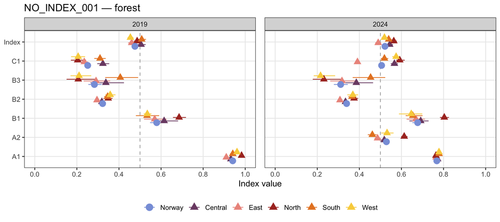

```r
plot_index_forest(
  forest_index$summaries,
  title = "NO_INDEX_001 — forest"
)
```

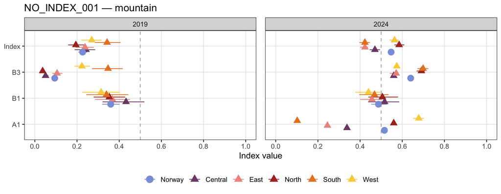

```r
plot_index_forest(
  mountain_index$summaries,
  title = "NO_INDEX_001 — mountain"
)
```

## 5. Export file

```r
export_index_results(
  forest_index$distributions,
  here("data/results_NO_INDEX_001_forest_v1.0.0.csv")
)

export_index_results(
  mountain_index$distributions,
  here("data/results_NO_INDEX_001_mountain_v1.0.0.csv")
)
```